# HW6

### Chisq for HD and Marital status

```r
chisq.test(HDover$heart_disease,HDover$ever_married)
```

```
    Pearson's Chi-squared test with Yates' continuity correction

data:  HDover$heart_disease and HDover$ever_married
X-squared = 84.485, df = 1, p-value < 2.2e-16
```

### Chisq for HD and Residence type

```r
chisq.test(HDover$heart_disease,HDover$Residence_type)
```

```
    Pearson's Chi-squared test with Yates' continuity correction

data:  HDover$heart_disease and HDover$Residence_type
X-squared = 1.5975, df = 1, p-value = 0.2063
```

### Chisq for HD and Work type

```r
chisq.test(HDover$heart_disease,HDover$work_type)
```

```
    Pearson's Chi-squared test

data:  HDover$heart_disease and HDover$work_type
X-squared = 119.73, df = 3, p-value < 2.2e-16
```

```r
NumericHD <- subset(HDover, select= c("age","avg_glucose_level","bmi"))
dim(NumericHD)
```

```
[1] 5340    3
```

```r
t.test(age ~ heart_disease, data = HDover)
```

```
    Welch Two Sample t-test

data:  age by heart_disease
t = -51.573, df = 4356.9, p-value < 2.2e-16
alternative hypothesis: true difference in means between group No and group Yes is not equal to 0
95 percent confidence interval:
 -21.03291 -19.49237
sample estimates:
 mean in group No mean in group Yes
         49.15071          69.41335
```

```r
t.test(bmi ~ heart_disease, data = HDover)
```

```
    Welch Two Sample t-test

data:  bmi by heart_disease
t = -0.41206, df = 4881, p-value = 0.6803
alternative hypothesis: true difference in means between group No and group Yes is not equal to 0
95 percent confidence interval:
 -0.4037695  0.2635147
sample estimates:
 mean in group No mean in group Yes
         30.28246          30.35259
```

```r
t.test(avg_glucose_level ~ heart_disease, data = HDover)
```

```
    Welch Two Sample t-test

data:  avg_glucose_level by heart_disease
t = -18.418, df = 4952.8, p-value < 2.2e-16
alternative hypothesis: true difference in means between group No and group Yes is not equal to 0
95 percent confidence interval:
 -29.98902 -24.21915
sample estimates:
 mean in group No mean in group Yes
         106.1215          133.2256
```

```r
summary(NumericHD)
```

```
      age        avg_glucose_level      bmi
 Min.   :18.00   Min.   : 55.12    Min.   :11.30
 1st Qu.:48.00   1st Qu.: 78.95    1st Qu.:26.10
 Median :63.00   Median : 96.58    Median :29.50
 Mean   :59.27   Mean   :119.65    Mean   :30.32
 3rd Qu.:74.00   3rd Qu.:150.45    3rd Qu.:33.80
 Max.   :82.00   Max.   :267.60    Max.   :78.00
```

```r
sapply(NumericHD, sd, na.rm=TRUE)
```

```
              age avg_glucose_level               bmi
        17.578299         55.423278          6.220602
```

#### OBSERVATION TO RESEARCH QUESTION 1:

Based on p<0.05, we can identify that almost all the variables namely gender, age, hypertension, marital status, work type, average glucose level, smoking_status and stroke are prevalent to people with heart disease. Only two variables, residence type and BMI, failed to reject the null hypothesis with a p-value = 0.2063 and p-value = 0.6803, respectively. Thus, BMI and residence type are not statistically significant in the prevalence of heart disease.

#### RESEARCH QUESTION 2: Are people who formerly smoked also less likely to have heart disease than smokers?

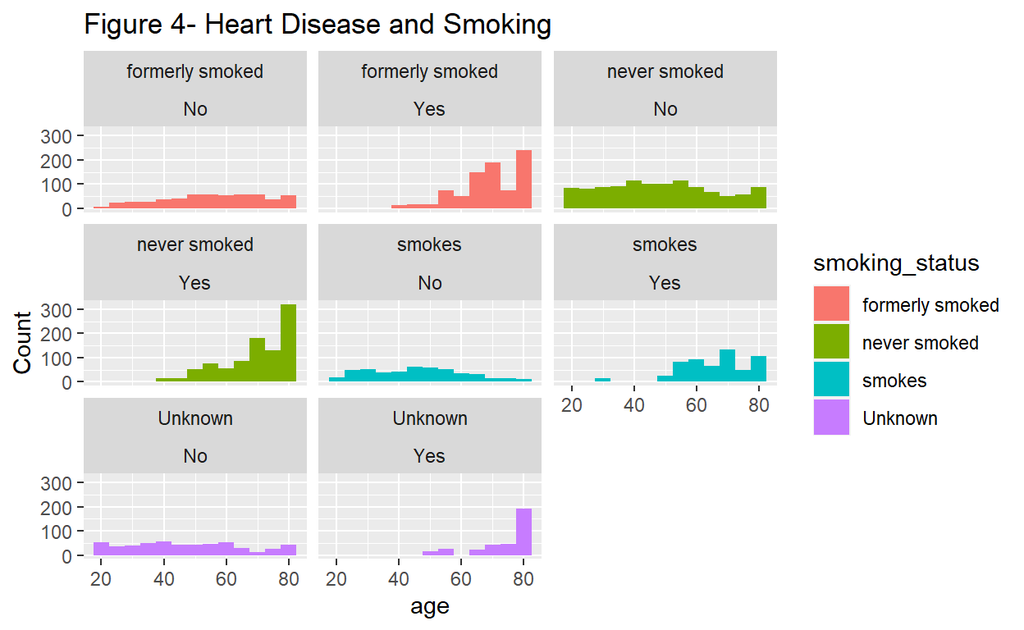

```r
ggplot(HDover, aes(x=age, fill=smoking_status))+
  geom_histogram(binwidth = 5)+
  facet_wrap(vars(smoking_status,heart_disease))+
  labs(x="age", y="Count", title = "Figure 4- Heart Disease and Smoking")
```

### Chisq for HD and Smoking Status

```r
chisq.test(HDover$heart_disease,HDover$smoking_status)
```

```
    Pearson's Chi-squared test

data:  HDover$heart_disease and HDover$smoking_status
X-squared = 133.14, df = 3, p-value < 2.2e-16
```

```r
YesHDover <- subset(HDover, heart_disease == "Yes", select= c("gender","age","hypertension","heart_disease","ever_married","work_type","Residence_type","avg_glucose_level","bmi","smoking_status","stroke"))
dim(YesHDover)
```

```
[1] 2666   11
```

### TABLE 1

```r
YesHDover %>%
    count(smoking_status, sort = TRUE) %>%
  head(4)
```

```
   smoking_status   n
1    never smoked 929
2 formerly smoked 822
3          smokes 569
4         Unknown 346
```

#### RESEARCH QUESTION 3. Are older people more likely to have obesity and diabetes? For this question, we will use the CDC definition of obesity as BMI>or=30 and diabetes as average glucose levels over 200.

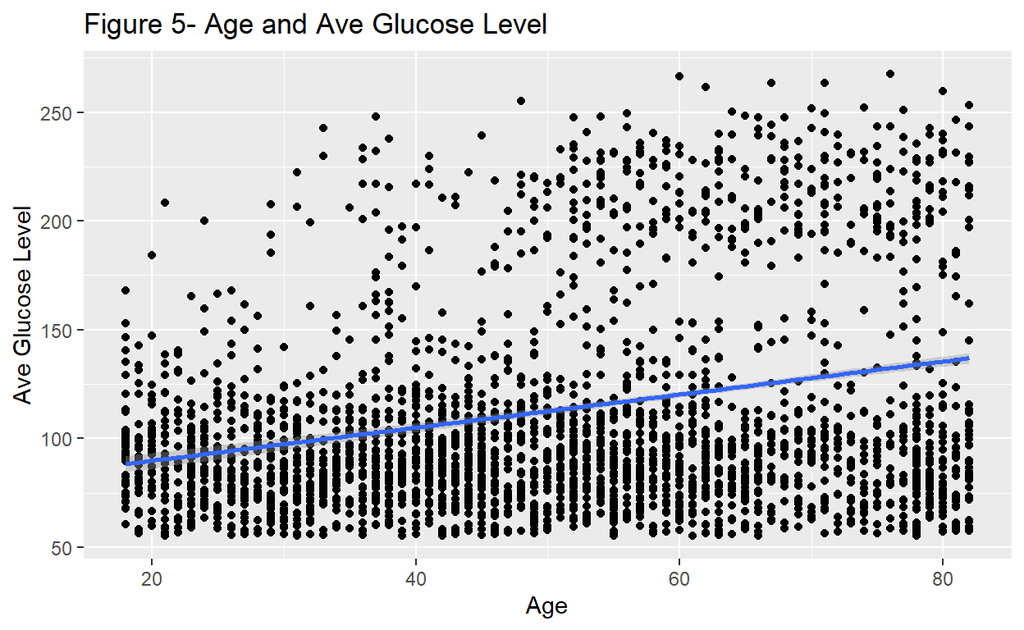

```r
ggplot(HDover, aes(x = age, y = avg_glucose_level)) +
    geom_point() +
    geom_smooth(method = "lm") +
    labs(x="Age", y="Ave Glucose Level", title = "Figure 5- Age and Ave Glucose Level")
```

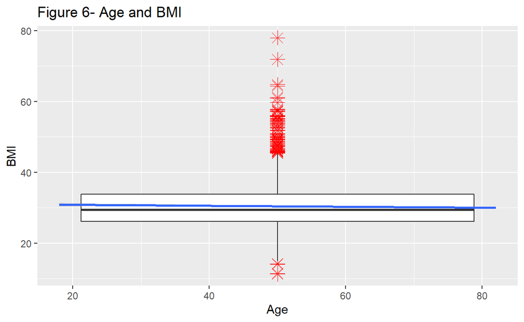

```r
ggplot(HDover, aes(x = age, y = bmi, color=bmi)) +
    geom_boxplot(outlier.colour="red", outlier.shape=8,
                outlier.size=4) +
    geom_smooth(method = "lm") +
    labs(x="Age", y="BMI", title = "Figure 6- Age and BMI")
```

```r
HDover.aov <- aov(age ~ bmi + avg_glucose_level, data = HDover)
# Summary of the analysis
summary(HDover.aov)
```

```
                    Df  Sum Sq Mean Sq F value Pr(>F)
bmi                  1    2427    2427   8.387 0.0038 **
avg_glucose_level    1  102565  102565 354.357 <2e-16 ***
Residuals         5337 1544740     289
---
Signif. codes:  0 '***' 0.001 '**' 0.01 '*' 0.05 '.' 0.1 ' ' 1
```

#### OBSERVATION TO RESEARCH QUESTION 3:

Both BMI and average glucose levels are statistically significant to age. On Figure 5, we can see a positive correlation that average glucose levels increase as people get older. Although we can not determine if the rise in glucose levels (mean=119.65) are significant to clinically define it as diabetes (glucose >200). The data set also did not define if average glucose levels was fasting blood sugar or not. This is important because is the glucose level is under “Fasting conditions” , then diabetes is defined as over 100. With our data set mean=119.65, if under “fasting conditions”, the average of population in data set is considered diabetic.

THINGS LEFT TO DO: Clean up final paper. Complete reflections and summarize conclusions. Explain visualizations in detail–e.g. rationale

#### BIBLIOGRAPHY:

1. Centers for Disease Control and Prevention. (2022, January 13). FASTSTATS - leading causes of death. Centers for Disease Control and Prevention. Retrieved January 16, 2022, from https://www.cdc.gov/nchs/fastats/leading-causes-of-death.htm
2. Centers for Disease Control and Prevention. (2021, September 27). Adult obesity prevalence maps. Centers for Disease Control and Prevention. Retrieved January 18, 2022, from https://www.cdc.gov/obesity/data/prevalence-maps.html#age
3. Fedesoriano. (2021, January 26). Stroke prediction dataset. Kaggle. Retrieved January 17, 2022, from https://www.kaggle.com/fedesoriano/stroke-prediction-dataset
4. Grolemund, H. W. and G. (n.d.). R for data science. Welcome | R for Data Science. Retrieved January 17, 2022, from https://r4ds.had.co.nz/index.html
5. R as programming language
6. Finnstats. (2021, April 13). Random Forest in R: R-bloggers. R. Retrieved January 17, 2022, from https://www.r-bloggers.com/2021/04/random-forest-in-r/